# Pemodelan ARIMA - Pendugaan Parameter, Diagnostik Model, dan Peramalan

Author

Windi Pangesti

Published

September 30, 2025

## 1 Packages

```r
library(ggplot2)
library(tsibble)
library(tseries)
library(MASS)
library(forecast)
library(TSA)
library(TTR)
library(aTSA)
library(graphics)
```

## 2 Data Bangkitan

### 2.1 Pembangkitan Data

Data yang akan dibangkitkan adalah data dengan model MA(2) sebagai berikut.

```r
set.seed(99)
ma2 <- arima.sim(list(order = c(0,0,2), ma = c(0.55,0.65)), n = 175)+4
ma2
```

```
Time Series:
Start = 1
End = 175
Frequency = 1
  [1] 4.49071631 4.80394208 3.93837292 4.21162120 2.96778088 4.09424753
  [7] 3.34367706 2.82374946 2.30572186 3.67012008 4.77215717 2.50298361
 [13] 0.06689652 0.69719194 1.62952003 2.03843466 3.28275389 3.41093311
 [19] 5.57205655 5.53304026 5.06876470 4.11188578 3.99453461 4.45028419
 [25] 5.13185970 4.18878528 2.77669801 4.29314034 5.25424896 6.11546992
 [31] 4.99383232 4.34030238 1.68064153 1.45459776 1.55933893 3.07120223
 [37] 3.99958888 4.41679260 4.36932382 2.60366790 2.88436115 1.20290343
 [43] 1.58546297 0.87504167 1.43567718 1.74447003 4.58115546 4.19264317
 [49] 3.41497257 3.65617694 3.64870703 4.18915281 2.91427928 3.06953017
 [55] 2.72924825 4.05224518 3.19315725 3.13139205 2.98300418 3.30952700
 [61] 3.38662568 3.93815667 2.75216183 2.22537215 2.75469274 3.27920726
```

[output cut: 19 more lines]

Data kemudian dibagi menjadi data latih dan data uji. Pembagian kali ini dilakukan dengan proporsi / perbandingan, yaitu 80:20.

```r
ma2 <- ma2[-c(1:25)]
ma2.train <- ma2[1:120]
ma2.test <- ma2[121:150]
```

### 2.2 Eksplorasi Data

Sebelum masuk dalam tahap pemodelan, dilakukan eksplorasi data dengan plot deret waktu untuk melihat pola data.

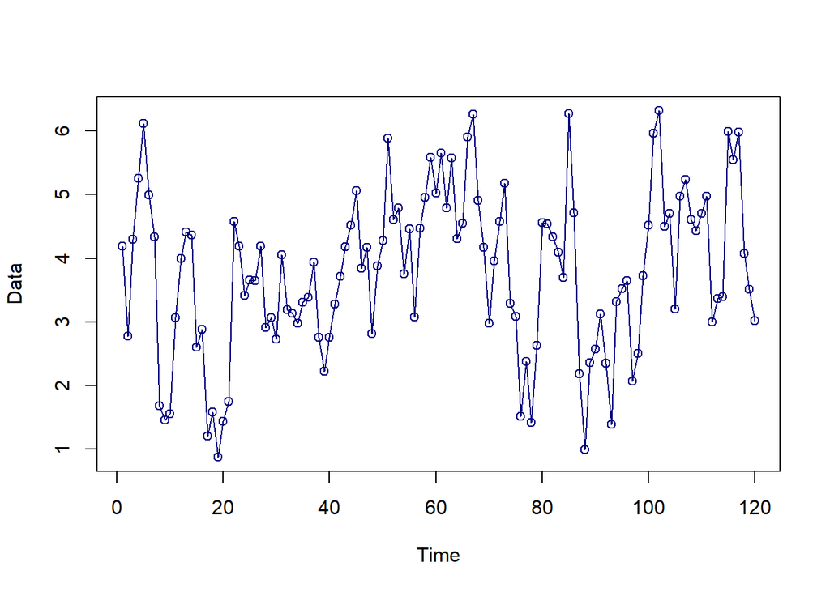

```r
#--PLOT TIME SERIES--#
plot(ma2.train,
     col = "navyblue",
     lwd = 1,
     type = "o",
     xlab = "Time",
     ylab = "Data")
```

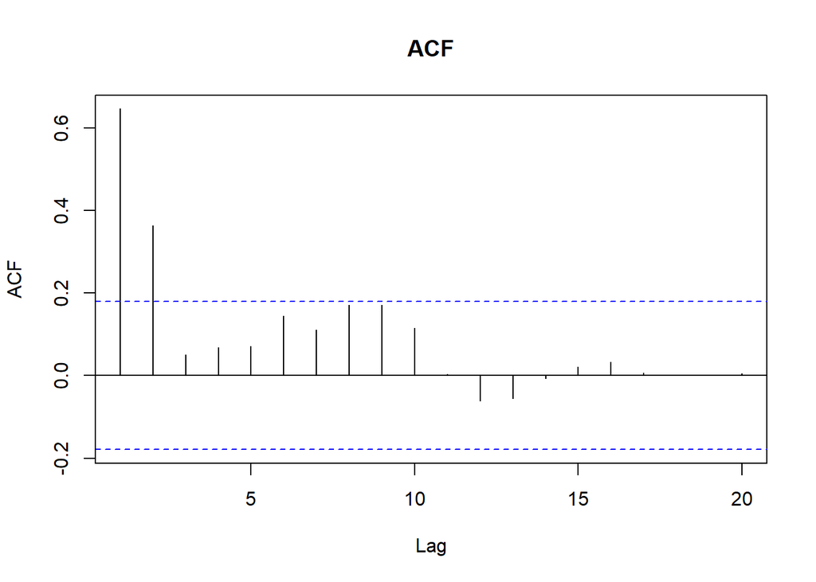

```r
#--CEK KESTASIONERAN---#
acf(ma2.train, main="ACF", lag.max=20)
```

Berdasarkan plot ACF di atas, dapat dilihat bahwa plot *cuts off* pada *lag* ke-2. Hal ini sesuai dengan proses pembangkitan model MA(2).

```r
tseries::adf.test(ma2.train)
```

```
    Augmented Dickey-Fuller Test

data:  ma2.train
Dickey-Fuller = -3.96, Lag order = 4, p-value = 0.01358
alternative hypothesis: stationary
```

```r
#stasioner
```

$H_0$ : Data tidak stasioner dalam rataan

$H_1$ : Data stasioner dalam rataan

Berdasarkan uji ADF tersebut, didapat *p-value* sebesar 0.01358 yang lebih kecil dari taraf nyata 5% sehingga tolak $H_0$ dan menandakan bahwa data stasioner dalam rataan. Hal ini sesuai dengan hasil eksplorasi menggunakan plot time series dan plot ACF.

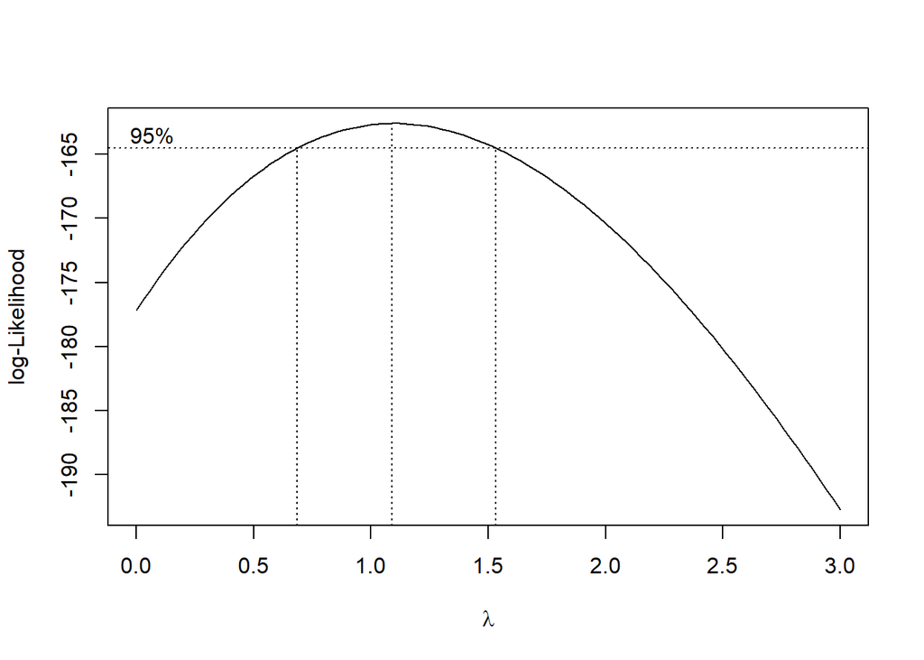

```r
index <- seq(1:120)

# Box-Cox
bc <- boxcox(
  ma2.train~index,
  lambda = seq(0, 3, by = 1)
)
```

```r
# Nilai lambda optimum
lambda <- bc$x[which.max(bc$y)]
lambda
```

```
[1] 1.090909
```

```r
# Selang kepercayaan 95% untuk lambda
ci_lambda <- bc$x[bc$y > max(bc$y) - 0.5 * qchisq(0.95, 1)]

# Batas bawah dan batas atas
ci_lower <- min(ci_lambda)
ci_upper <- max(ci_lambda)

c(Batas_Bawah = ci_lower, Batas_Atas = ci_upper)
```

```
Batas_Bawah  Batas_Atas
  0.6969697   1.5151515
```

Gambar di atas menunjukkan nilai *rounded value* ($\lambda$) optimum sebesar 1,09 dan pada selang kepercayaan 95% nilai memiliki batas bawah 0,69 dan batas atas 1,515. Selang tersebut memuat nilai satu sehingga dapat dikatakan bahwa data bangkitan stasioner dalam ragam.

### 2.3 Spesifikasi Model

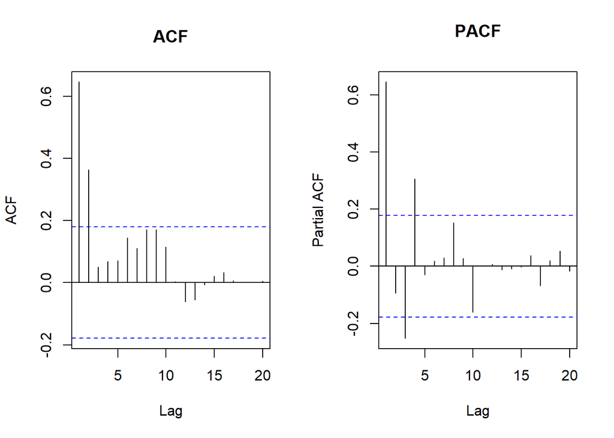

```r
#---SPESIFIKASI MODEL---#
par(mfrow = c(1,2))
acf(ma2.train, main="ACF", lag.max=20) #ARIMA(0,0,2)
pacf(ma2.train, main="PACF", lag.max=20) #ARIMA(1,0,0)
```

```r
par(mfrow = c(1,1))
```

```r
eacf(ma2.train)
```

```
AR/MA
  0 1 2 3 4 5 6 7 8 9 10 11 12 13
0 x x o o o o o o o o o  o  o  o
1 o x x o o o o o o o o  o  o  o
2 x x x o o o o o o o o  o  o  o
3 x x x o o o o o o o o  o  o  o
4 o o o x o o o o o o o  o  o  o
5 x o o x o o o o o o o  o  o  o
6 x o o o o o o o x o o  o  o  o
7 o o o o o x o o o o o  o  o  o
```

```r
#ARIMA(0,0,2) #ARIMA(1,0,3) #ARIMA(2,0,3) #ARIMA(3,0,3)
#Terdapat 5 model tentatif
```

Menggunakan plot EACF, dapat diambil beberapa model dengan melihat ujung segitiga yang terbentuk, antara lain ARIMA(0,0,2), ARIMA(1,0,3), ARIMA(2,0,3), dan ARIMA(3,0,3).

### 2.4 Pendugaan Parameter

Selanjutnya akan dilakukan pendugaan parameter kelima model ARIMA yang terbentuk sebelumnya. Pendugaan dilakukan dengan fungsi `Arima()` yang dilanjutkan dengan melihat nilai AIC pada ringkasan data dan melihat signifikansi parameter.

```r
#---PENDUGAAN PARAMETER MODEL---#
model1.ma2=Arima(ma2.train, order=c(0,0,2),method="ML")
summary(model1.ma2) #AIC=326.87
```

```
Series: ma2.train
ARIMA(0,0,2) with non-zero mean

Coefficients:
         ma1     ma2    mean
      0.6953  0.5349  3.7918
s.e.  0.0829  0.0673  0.1841

sigma^2 = 0.8497:  log likelihood = -159.44
AIC=326.87   AICc=327.22   BIC=338.02

Training set error measures:
                       ME     RMSE     MAE       MPE     MAPE     MASE
Training set -0.004254881 0.910219 0.73195 -9.740748 24.85194 0.852277
                   ACF1
Training set 0.05965759
```

```r
lmtest::coeftest(model1.ma2) #seluruh parameter signifikan
```

```
z test of coefficients:

          Estimate Std. Error z value  Pr(>|z|)
ma1       0.695312   0.082903  8.3871 < 2.2e-16 ***
ma2       0.534929   0.067337  7.9441 1.957e-15 ***
intercept 3.791764   0.184115 20.5946 < 2.2e-16 ***
---
Signif. codes:  0 '***' 0.001 '**' 0.01 '*' 0.05 '.' 0.1 ' ' 1
```

```r
model2.ma2=Arima(ma2.train, order=c(1,0,0),method="ML")
summary(model2.ma2) #AIC=340.47
```

```
Series: ma2.train
ARIMA(1,0,0) with non-zero mean

Coefficients:
         ar1    mean
      0.6428  3.7815
s.e.  0.0690  0.2450

sigma^2 = 0.9625:  log likelihood = -167.24
AIC=340.47   AICc=340.68   BIC=348.84

Training set error measures:
                       ME      RMSE       MAE       MPE     MAPE      MASE
Training set -0.002975587 0.9728552 0.7723112 -10.61667 26.61199 0.8992733
                   ACF1
Training set 0.06622426
```

```r
lmtest::coeftest(model2.ma2) #seluruh parameter signifikan
```

```
z test of coefficients:

          Estimate Std. Error z value  Pr(>|z|)
ar1       0.642823   0.069023  9.3131 < 2.2e-16 ***
intercept 3.781515   0.245000 15.4348 < 2.2e-16 ***
---
Signif. codes:  0 '***' 0.001 '**' 0.01 '*' 0.05 '.' 0.1 ' ' 1
```

```r
model3.ma2=Arima(ma2.train, order=c(1,0,3),method="ML")
summary(model3.ma2) #AIC=329.22
```

```
Series: ma2.train
ARIMA(1,0,3) with non-zero mean

Coefficients:
         ar1    ma1     ma2     ma3    mean
      0.0610  0.684  0.6137  0.0934  3.7918
s.e.  0.4257  0.416  0.3263  0.2714  0.2083

sigma^2 = 0.8518:  log likelihood = -158.61
AIC=329.22   AICc=329.96   BIC=345.94

Training set error measures:
                       ME      RMSE      MAE       MPE     MAPE     MASE
Training set -0.004465851 0.9034798 0.725319 -8.862145 24.28653 0.844556
                    ACF1
Training set 0.005156424
```

```r
lmtest::coeftest(model3.ma2) #tidak ada yang signifikan
```

```
z test of coefficients:

          Estimate Std. Error z value Pr(>|z|)
ar1       0.060970   0.425686  0.1432  0.88611
ma1       0.684021   0.415962  1.6444  0.10009
ma2       0.613727   0.326319  1.8808  0.06001 .
ma3       0.093411   0.271412  0.3442  0.73072
intercept 3.791809   0.208338 18.2003  < 2e-16 ***
---
Signif. codes:  0 '***' 0.001 '**' 0.01 '*' 0.05 '.' 0.1 ' ' 1
```

```r
model4.ma2=Arima(ma2.train, order=c(2,0,3),method="ML")
summary(model4.ma2) #AIC=330.6
```

```
Series: ma2.train
ARIMA(2,0,3) with non-zero mean

Coefficients:
         ar1      ar2     ma1     ma2     ma3    mean
      0.2670  -0.1935  0.4749  0.6454  0.0524  3.7925
s.e.  0.4227   0.1744  0.4136  0.3050  0.2587  0.1916

sigma^2 = 0.8538:  log likelihood = -158.3
AIC=330.6   AICc=331.6   BIC=350.11

Training set error measures:
                       ME      RMSE       MAE       MPE     MAPE      MASE
Training set -0.004511346 0.9006288 0.7299239 -9.000208 24.57932 0.8499178
                    ACF1
Training set 0.006394934
```

```r
lmtest::coeftest(model4.ma2) #hanya ma2 yang signifikan
```

```
z test of coefficients:

           Estimate Std. Error z value Pr(>|z|)
ar1        0.267023   0.422731  0.6317  0.52761
ar2       -0.193470   0.174380 -1.1095  0.26723
ma1        0.474856   0.413641  1.1480  0.25097
ma2        0.645418   0.304955  2.1164  0.03431 *
ma3        0.052372   0.258742  0.2024  0.83960
intercept  3.792457   0.191625 19.7910  < 2e-16 ***
---
Signif. codes:  0 '***' 0.001 '**' 0.01 '*' 0.05 '.' 0.1 ' ' 1
```

```r
model5.ma2=Arima(ma2.train, order=c(3,0,3),method="ML")
summary(model5.ma2) #AIC=329.87
```

```
Series: ma2.train
ARIMA(3,0,3) with non-zero mean

Coefficients:
          ar1     ar2      ar3     ma1     ma2     ma3    mean
      -0.3810  0.2176  -0.2170  1.1432  0.7306  0.3543  3.7947
s.e.   0.3026  0.1535   0.1541  0.2896  0.3056  0.2426  0.1890

sigma^2 = 0.8418:  log likelihood = -156.93
AIC=329.87   AICc=331.16   BIC=352.17

Training set error measures:
                       ME      RMSE     MAE       MPE     MAPE      MASE
Training set -0.004402562 0.8903241 0.70915 -8.698653 23.76772 0.8257288
                   ACF1
Training set 0.01679809
```

```r
lmtest::coeftest(model5.ma2) #hanya ma1 dan ma2 yang signifikan
```

```
z test of coefficients:

          Estimate Std. Error z value  Pr(>|z|)
ar1       -0.38103    0.30264 -1.2590    0.2080
ar2        0.21757    0.15355  1.4170    0.1565
ar3       -0.21701    0.15408 -1.4084    0.1590
ma1        1.14318    0.28962  3.9472 7.909e-05 ***
ma2        0.73062    0.30555  2.3911    0.0168 *
ma3        0.35428    0.24258  1.4605    0.1442
intercept  3.79470    0.18897 20.0808 < 2.2e-16 ***
---
Signif. codes:  0 '***' 0.001 '**' 0.01 '*' 0.05 '.' 0.1 ' ' 1
```

```r
#model yang dipilih adalah model 1, yaitu ARIMA(0,0,2)
```

```r
hasil_model <- data.frame(
  Model = c("ARIMA(0,0,2)",
            "ARIMA(1,0,0)",
            "ARIMA(1,0,3)",
            "ARIMA(2,0,3)",
            "ARIMA(3,0,3)"),
  AIC = c(
    AIC(model1.ma2),
    AIC(model2.ma2),
    AIC(model3.ma2),
    AIC(model4.ma2),
    AIC(model5.ma2)
  ),
  BIC = c(
    BIC(model1.ma2),
    BIC(model2.ma2),
    BIC(model3.ma2),
    BIC(model4.ma2),
    BIC(model5.ma2)
  )
)

hasil_model
```

```
         Model      AIC      BIC
1 ARIMA(0,0,2) 326.8723 338.0222
2 ARIMA(1,0,0) 340.4735 348.8360
3 ARIMA(1,0,3) 329.2172 345.9421
4 ARIMA(2,0,3) 330.5985 350.1109
5 ARIMA(3,0,3) 329.8664 352.1664
```

Berdasarkan pendugaan parameter di atas, nilai AIC terkecil dimiliki oleh model ARIMA(0,0,2) dan parameter model ARIMA(0,0,2) juga seluruhnya signifikan sehingga model yang dipilih adalah model ARIMA(0,0,2).

### 2.5 Analisis Sisaan

Model terbaik hasil identifikasi kemudian dicek asumsi sisaannya. Sisaan model ARIMA harus memenuhi asumsi normalitas, kebebasan, dan kehomogenan ragam. Diagnostik model dilakukan secara eksplorasi dan uji formal.

#### 2.5.1 Eksplorasi Sisaan

```r
#Eksplorasi
sisaan.ma2 <- model1.ma2$residuals
par(mfrow=c(2,2))

#qqnorm(sisaan.ma2)
#qqline(sisaan.ma2, col = "blue", lwd = 2)
car::qqPlot(sisaan.ma2)
```

```
[1] 87 85
```

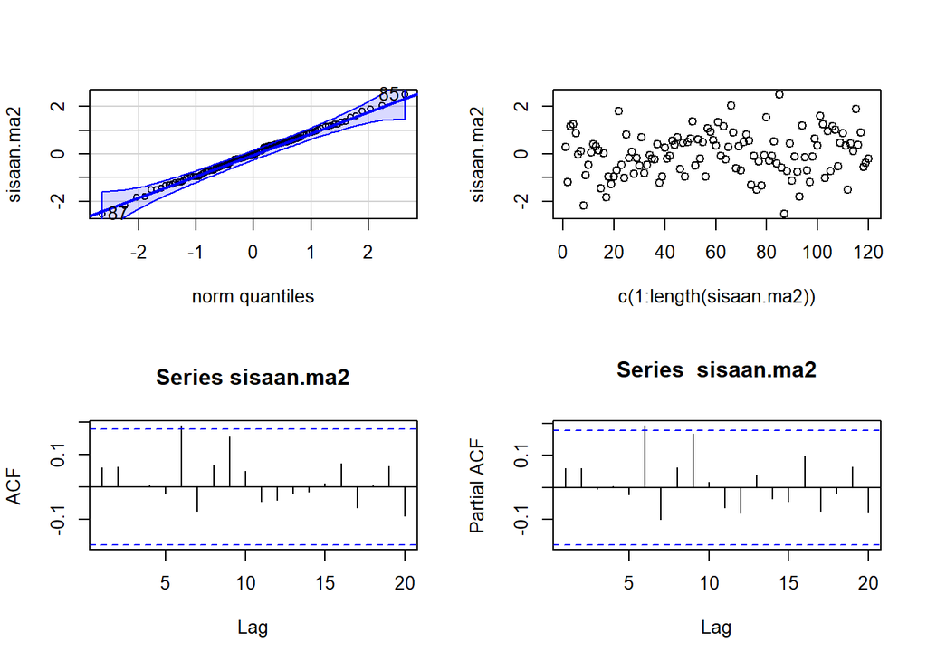

```r
plot(c(1:length(sisaan.ma2)),sisaan.ma2)

# ACFF dan PACF sisaan
acf(sisaan.ma2)
pacf(sisaan.ma2)
```

```r
par(mfrow = c(2,2))
```

Berdasarkan plot kuantil-kuantil normal, secara eksplorasi ditunjukkan sisaan menyebar normal mengikuti garis $45^{\circ}$. Kemudian dapat dilihat juga lebar pita sisaan yang cenderung sama menandakan bahwa sisaan memiliki ragam yang homogen. Akan tetapi, plot ACF dan PACF sisaan ARIMA(0,0,2) signifikan pada lag ke-6 sehingga sisaan tidak saling bebas. Kondisi ini akan diuji lebih lanjut dengan uji formal.

#### 2.5.2 Uji Formal

```r
#1) Sisaan Menyebar Normal
ks.test(sisaan.ma2,"pnorm")
```

```
    Asymptotic one-sample Kolmogorov-Smirnov test

data:  sisaan.ma2
D = 0.043157, p-value = 0.9788
alternative hypothesis: two-sided
```

```r
#gagal tolak H0 > sisaan menyebar normal
```

Selain dengan eksplorasi, asumsi tersebut dapat diuji menggunakan uji formal. Pada tahapan ini uji formal yang digunakan untuk normalitas adalah uji Kolmogorov-Smirnov (KS). Hipotesis pada uji KS adalah sebagai berikut.

$H_0$ : Sisaan menyebar normal

$H_1$ : Sisaan tidak menyebar normal

Berdasarkan uji KS tersebut, didapat *p-value* sebesar 0.9788 yang lebih besar dari taraf nyata 5% sehingga gagal tolak $H_0$ dan menandakan bahwa sisaan menyebar normal. Hal ini sesuai dengan hasil eksplorasi menggunakan plot kuantil-kuantil normal.

```r
#2) Sisaan saling bebas/tidak ada autokorelasi
Box.test(sisaan.ma2, type = "Ljung")
```

```
    Box-Ljung test

data:  sisaan.ma2
X-squared = 0.43785, df = 1, p-value = 0.5082
```

```r
#gagal tolak H0 > sisaan saling bebas
```

Selanjutnya akan dilakukan uji formal untuk kebebasan sisaan menggunakan uji Ljung-Box. Hipotesis yang digunakan adalah sebagai berikut.

$H_0$ : Sisaan saling bebas

$H_1$ : Sisaan tidak tidak saling bebas

Berdasarkan uji Ljung-Box tersebut, didapat *p-value* sebesar 0.5082 yang lebih besar dari taraf nyata 5% sehingga gagal tolak $H_0$ dan menandakan bahwa sisaan saling bebas. Hal ini berbeda dengan eksplorasi.

```r
#3) Sisaan homogen
Box.test((sisaan.ma2)^2, type = "Ljung")
```

```
    Box-Ljung test

data:  (sisaan.ma2)^2
X-squared = 2.4711, df = 1, p-value = 0.116
```

```r
#gagal tolak H0 > sisaan homogen
```

Hipotesis yang digunakan untuk uji kehomogenan ragam adalah sebagai berikut.

$H_0$ : Ragam sisaan homogen

$H_1$ : Ragam sisaan tidak homogen

Berdasarkan uji Ljung-Box terhadap sisaan kuadrat tersebut, didapat *p-value* sebesar 0.116 yang lebih besar dari taraf nyata 5% sehingga gagal tolak $H_0$ dan menandakan bahwa ragam sisaan homogen.

```r
#4) Nilai tengah sisaan sama dengan nol
t.test(sisaan.ma2, mu = 0, conf.level = 0.95)
```

```
    One Sample t-test

data:  sisaan.ma2
t = -0.050994, df = 119, p-value = 0.9594
alternative hypothesis: true mean is not equal to 0
95 percent confidence interval:
 -0.1694719  0.1609621
sample estimates:
   mean of x
-0.004254881
```

```r
#gagal tolak h0 > nilai tengah sisaan sama dengan 0
```

Terakhir, dengan uji-t, akan dicek apakah nilai tengah sisaan sama dengan nol. Hipotesis yang diujikan sebagai berikut.

$H_0$ : nilai tengah sisaan sama dengan 0

$H_1$ : nilai tengah sisaan tidak sama dengan 0

Berdasarkan uji-ttersebut, didapat *p-value* sebesar 0.9594 yang lebih besar dari taraf nyata 5% sehingga gagal tolak $H_0$ dan menandakan bahwa nilai tengah sisaan sama dengan nol. Hal ini berbeda dengan eksplorasi.

### 2.6 Overfitting

Tahapan selanjutnya adalah *overfitting* dilakukan dengan menaikkan orde AR(p) dan MA(q) dari model ARIMA(0,0,2) untuk melihat apakah terdapat model lain yang lebih baik dari model saat ini. Kandidat model *overfitting* adalah ARIMA(1,0,2) dan ARIMA(0,0,3).

```r
#---OVERFITTING---#
model1a.ma2=Arima(ma2.train, order=c(1,0,2),method="ML")
summary(model1a.ma2) #327.31
```

```
Series: ma2.train
ARIMA(1,0,2) with non-zero mean

Coefficients:
         ar1     ma1     ma2    mean
      0.1990  0.5451  0.5029  3.7917
s.e.  0.1412  0.1239  0.0836  0.2093

sigma^2 = 0.8453:  log likelihood = -158.65
AIC=327.31   AICc=327.84   BIC=341.25

Training set error measures:
                       ME      RMSE       MAE       MPE     MAPE      MASE
Training set -0.004448537 0.9039253 0.7240135 -8.892151 24.23053 0.8430358
                    ACF1
Training set 0.007803042
```

```r
lmtest::coeftest(model1a.ma2) #ar1 tidak signifikan
```

```
z test of coefficients:

          Estimate Std. Error z value  Pr(>|z|)
ar1       0.199039   0.141222  1.4094    0.1587
ma1       0.545109   0.123914  4.3991 1.087e-05 ***
ma2       0.502936   0.083609  6.0153 1.795e-09 ***
intercept 3.791724   0.209264 18.1193 < 2.2e-16 ***
---
Signif. codes:  0 '***' 0.001 '**' 0.01 '*' 0.05 '.' 0.1 ' ' 1
```

```r
model1b.ma2=Arima(ma2.train, order=c(0,0,3),method="ML")
summary(model1b.ma2) #327.24
```

```
Series: ma2.train
ARIMA(0,0,3) with non-zero mean

Coefficients:
         ma1    ma2     ma3    mean
      0.7415  0.656  0.1286  3.7916
s.e.  0.0878  0.118  0.0997  0.2067

sigma^2 = 0.8446:  log likelihood = -158.62
AIC=327.24   AICc=327.77   BIC=341.18

Training set error measures:
                       ME      RMSE       MAE      MPE     MAPE      MASE
Training set -0.004403296 0.9035497 0.7261616 -8.89926 24.34304 0.8455371
                    ACF1
Training set 0.007516805
```

```r
lmtest::coeftest(model1b.ma2) #ma3 tidak signifikan
```

```
z test of coefficients:

          Estimate Std. Error z value  Pr(>|z|)
ma1       0.741488   0.087816  8.4436 < 2.2e-16 ***
ma2       0.656016   0.118034  5.5579 2.731e-08 ***
ma3       0.128647   0.099655  1.2909    0.1967
intercept 3.791645   0.206722 18.3417 < 2.2e-16 ***
---
Signif. codes:  0 '***' 0.001 '**' 0.01 '*' 0.05 '.' 0.1 ' ' 1
```

```r
#model yang dipilih adalah model awal, yaitu ARIMA(0,0,2)
```

```r
overfitting <- data.frame(
  Model = c("ARIMA(1,0,2)","ARIMA(0,0,2)", "ARIMA(0,0,3)"),
  AIC   = c(AIC(model1a.ma2),AIC(model1.ma2), AIC(model1b.ma2)),
  BIC   = c(BIC(model1a.ma2),BIC(model1.ma2), BIC(model1b.ma2))
)

overfitting
```

```
         Model      AIC      BIC
1 ARIMA(1,0,2) 327.3095 341.2470
2 ARIMA(0,0,2) 326.8723 338.0222
3 ARIMA(0,0,3) 327.2393 341.1768
```

Berdasarkan kedua model hasil *overfitting* di atas, model ARIMA(1,0,2) dan ARIMA(0,0,3) memiliki AIC yang lebih besar dibandingkan dengan model ARIMA(0,0,2) dan parameter kedua model ARIMA(1,0,2) dan ARIMA(0,0,3) tidak seluruhnya signifikan. Oleh karena itu, model ARIMA(0,0,2) akan tetap digunakan untuk melakukan peramalan.

### 2.7 Peramalan

Peramalan dilakukan menggunakan fungsi `forecast()` . Contoh peramalan berikut ini dilakukan untuk 30 hari ke depan.

```r
#---FORECAST---#
ramalan <- forecast::forecast(model1.ma2, h = 30)
ramalan
```

```
    Point Forecast    Lo 80    Hi 80    Lo 95    Hi 95
121       3.438126 2.256773 4.619479 1.631403 5.244850
122       3.678541 2.239685 5.117397 1.478000 5.879082
123       3.791764 2.220250 5.363278 1.388341 6.195187
124       3.791764 2.220250 5.363278 1.388341 6.195187
125       3.791764 2.220250 5.363278 1.388341 6.195187
126       3.791764 2.220250 5.363278 1.388341 6.195187
127       3.791764 2.220250 5.363278 1.388341 6.195187
128       3.791764 2.220250 5.363278 1.388341 6.195187
129       3.791764 2.220250 5.363278 1.388341 6.195187
130       3.791764 2.220250 5.363278 1.388341 6.195187
131       3.791764 2.220250 5.363278 1.388341 6.195187
132       3.791764 2.220250 5.363278 1.388341 6.195187
133       3.791764 2.220250 5.363278 1.388341 6.195187
134       3.791764 2.220250 5.363278 1.388341 6.195187
```

[output cut: 16 more lines]

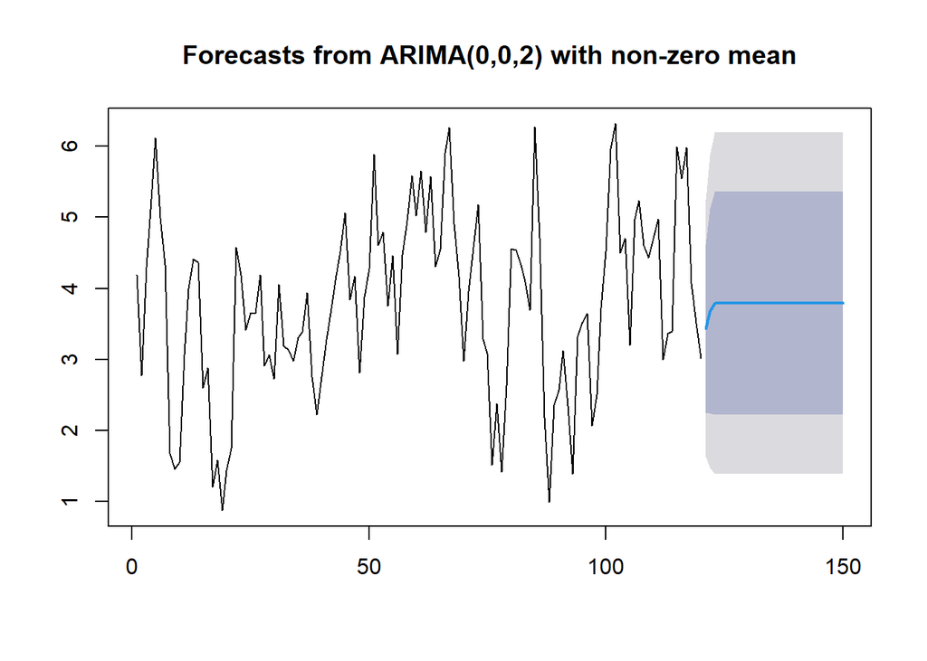

```r
data.ramalan <- ramalan$mean
plot(ramalan)
```

Berdasarkan hasil plot ramalan di atas, dapat dilihat bahwa ramalan ARIMA(0,0,2) cenderung meningkat di awal periode dan stabil hingga akhir periode. Selanjutnya, dapat dicari nilai akurasi antara hasil ramalan dengan data uji sebagai berikut.

```r
perbandingan<-matrix(data=c(ma2.test, data.ramalan),
                     nrow = 30, ncol = 2)
colnames(perbandingan)<-c("Aktual","Hasil Forecast")
perbandingan
```

```
        Aktual Hasil Forecast
 [1,] 3.712164       3.438126
 [2,] 3.355679       3.678541
 [3,] 5.327929       3.791764
 [4,] 2.712639       3.791764
 [5,] 3.482306       3.791764
 [6,] 3.957417       3.791764
 [7,] 5.616873       3.791764
 [8,] 6.115434       3.791764
 [9,] 4.363430       3.791764
[10,] 4.026694       3.791764
[11,] 4.065726       3.791764
[12,] 6.418521       3.791764
[13,] 6.457608       3.791764
[14,] 5.783138       3.791764
```

[output cut: 16 more lines]

```r
# Akurasi
accuracy(data.ramalan, ma2.test)
```

```
                ME     RMSE       MAE      MPE     MAPE
Test set 0.5059314 1.242369 0.9656338 4.625391 22.43956
```

## 3 Data Real

Digunakan data kurs yang dalam hal ini hanya digunakan data 500 periode awal

```r
datakurs<-rio::import("https://raw.githubusercontent.com/rizkynurhambali/praktikum-sta1341/main/Pertemuan%2067/kurs.csv")
datakurs <- datakurs[1:500,]
datakurs.ts<-ts(datakurs)
```

### 3.1 Eksplorasi Data

#### 3.1.1 Plot Data Penuh

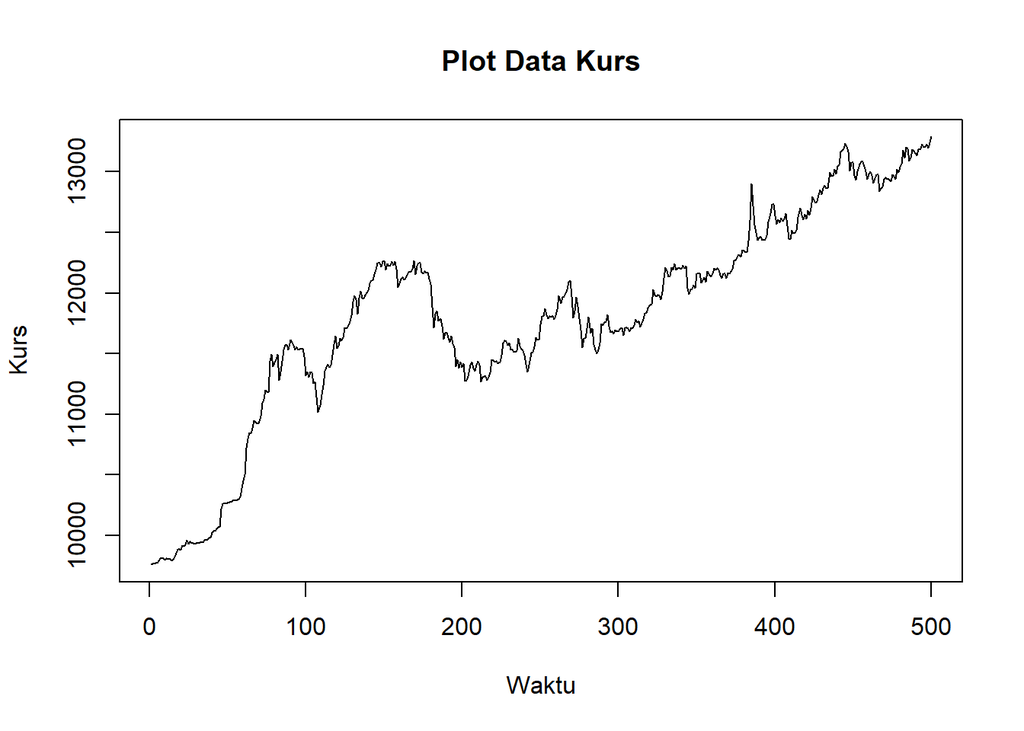

```r
plot.ts(datakurs.ts,
        lty = 1,
        xlab = "Waktu",
        ylab = "Kurs",
        main = "Plot Data Kurs")
```

Berdasarkan plot data deret waktu, terlihat bahwa data cenderung memiliki trend yang naik. Berdasarkan pola data, pembagian data latih dan data uji ditetapkan dengan proporsi 86%:14%.

#### 3.1.2 Plot Data Latih

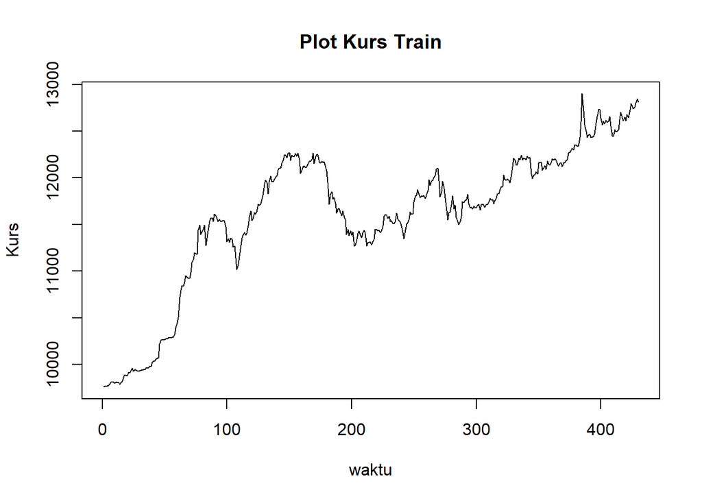

```r
kurstrain<-datakurs[1:430]
train.ts<-ts(kurstrain)
plot.ts(train.ts, lty=1, xlab="waktu", ylab="Kurs", main="Plot Kurs Train")
```

Berdasarkan plot data deret waktu pada data latih, terlihat bahwa data cenderung memiliki trend yang naik dan cenderung tidak bergerak pada nilai tengah tertentu. Hal ini mengindikasikan bahwa data tidak stasioner dalam rataan.

#### 3.1.3 Plot Data Uji

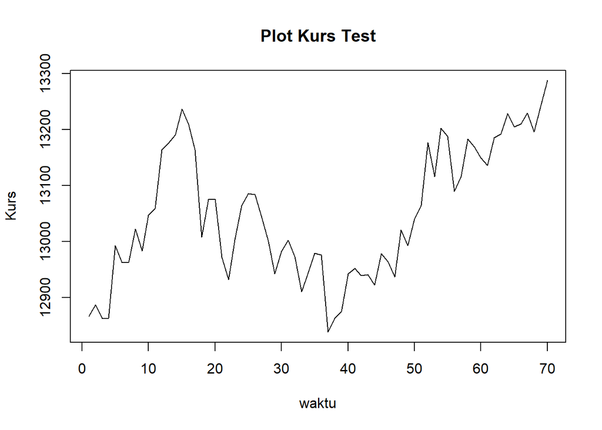

```r
kurstest<-datakurs[431:500]
test.ts<-ts(kurstest)
plot.ts(test.ts, lty=1, xlab="waktu", ylab="Kurs", main="Plot Kurs Test")
```

### 3.2 Uji Stasioneritas Data

#### 3.2.1 Plot ACF

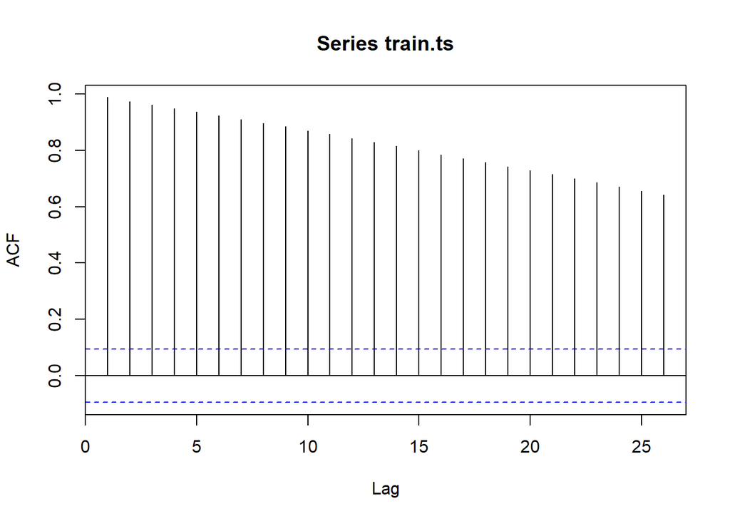

```r
acf(train.ts)
```

Berdasarkan plot ACF, terlihat bahwa plot ACF data menurun secara perlahan (*tails of slowly*). Hal ini juga menjadi indikasi bahwa data tidak stasioner dalam rataan

#### 3.2.2 Uji ADF

```r
tseries::adf.test(train.ts)
```

```
    Augmented Dickey-Fuller Test

data:  train.ts
Dickey-Fuller = -2.0526, Lag order = 7, p-value = 0.5553
alternative hypothesis: stationary
```

$H_0$ : Data tidak stasioner dalam rataan

$H_1$ : Data stasioner dalam rataan

Berdasarkan uji ADF tersebut, didapat *p-value* sebesar 0.5553 yang lebih besar dari taraf nyata 5% sehingga tak tolak $H_0$ dan menandakan bahwa data tidak stasioner dalam rataan. Hal ini sesuai dengan hasil eksplorasi menggunakan plot time series dan plot ACF, sehingga ketidakstasioneran model kedepannya harus ditangani

#### 3.2.3 Plot Box-Cox

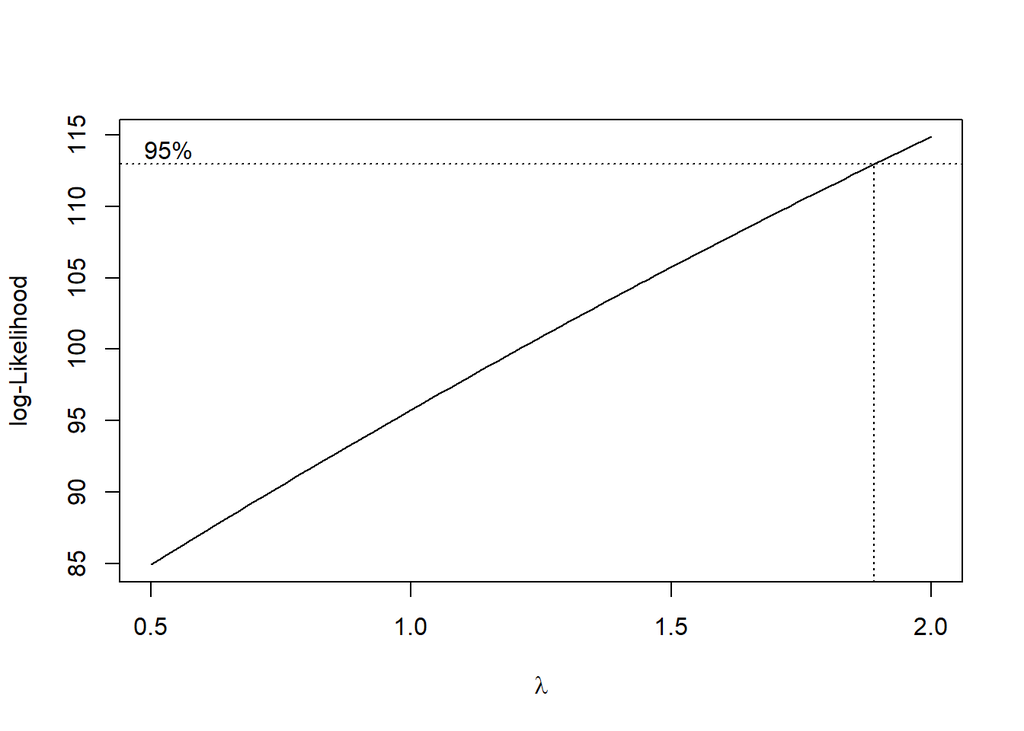

```r
index <- seq(1:430)

# Box-Cox
bc <- boxcox(train.ts ~ index, lambda = seq(0.5, 2, by = 0.1))
```

```r
# Nilai lambda optimum (rounded)
lambda_opt <- bc$x[which.max(bc$y)]
lambda_opt
```

```
[1] 2
```

```r
# Selang kepercayaan 95% untuk lambda
ci_lambda <- bc$x[bc$y > max(bc$y) - 0.5 * qchisq(0.95, df = 1)]

# Batas bawah dan batas atas
ci_lower <- min(ci_lambda)
ci_upper <- max(ci_lambda)

c(Batas_Bawah = ci_lower, Batas_Atas = ci_upper)
```

```
Batas_Bawah  Batas_Atas
   1.893939    2.000000
```

### 3.3 Penanganan Ketidakstasioneran Data

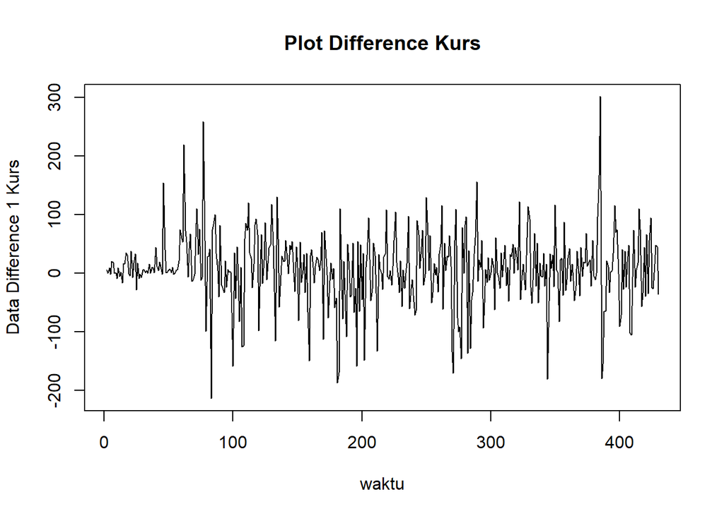

```r
# Dufferencing pertama
train.diff<-diff(train.ts,differences = 1)

# Plot hasil differencing
plot.ts(train.diff, lty=1, xlab="waktu", ylab="Data Difference 1 Kurs", main="Plot Difference Kurs")
```

Berdasarkan plot data deret waktu, terlihat bahwa data sudah stasioner dalam rataan ditandai dengan data bergerak pada nilai tengah tertentu (tidak terdapat trend ataupun musiman pada data)

#### 3.3.1 Plot ACF

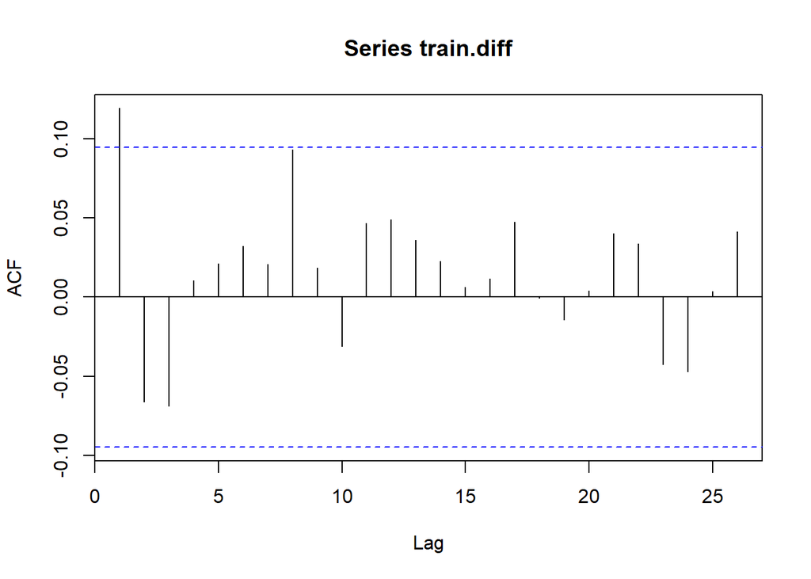

```r
acf(train.diff)
```

Berdasarkan plot tersebut, terlihat bahwa plot ACF cuts off pada lag ke 1. Hal ini menandakan data sudah stasioner dalam rataan dan ketidakstasioneran data telah berhasil tertangani.

#### 3.3.2 Uji ADF

```r
tseries::adf.test(train.diff)
```

```
    Augmented Dickey-Fuller Test

data:  train.diff
Dickey-Fuller = -6.3673, Lag order = 7, p-value = 0.01
alternative hypothesis: stationary
```

$H_0$ : Data tidak stasioner dalam rataan

$H_1$ : Data stasioner dalam rataan

Berdasarkan uji ADF tersebut, didapat *p-value* sebesar 0.01 yang lebih kecil dari taraf nyata 5% sehingga tolak $H_0$ atau data stasioner dalam rataan. Hal ini sesuai dengan hasil eksplorasi menggunakan plot time series dan plot ACF, sehingga dalam hal ini ketidakstasioneran data sudah berhasil ditangani dan dapat dilanjutkan ke pemodelan

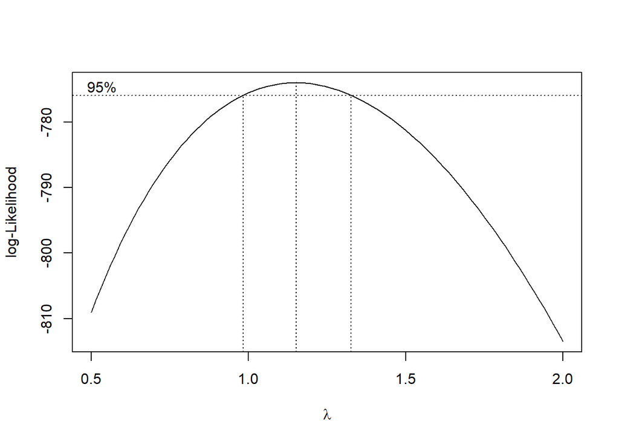

```r
library(MASS)

# 1. Sesuaikan panjang index karena differencing menghilangkan 1 observasi awal
index_diff <- seq(1:length(train.diff))

# 2. Cek apakah ada nilai negatif/nol. Jika ada, tambahkan konstanta (c)
# agar nilai minimum data menjadi > 0 (misalnya menjadi 1)
min_val <- min(train.diff)

if (min_val <= 0) {
  c <- abs(min_val) + 1
  train.diff_shifted <- train.diff + c
} else {
  train.diff_shifted <- train.diff
}

# 3. Plot Box-Cox pada data yang sudah di-shift
bc_diff <- boxcox(train.diff_shifted ~ index_diff, lambda = seq(0.5, 2, by = 0.1))
```

```r
# 4. Nilai lambda optimum (rounded)
lambda_opt_diff <- bc_diff$x[which.max(bc_diff$y)]
print(paste("Lambda optimum setelah diff:", lambda_opt_diff))
```

```
[1] "Lambda optimum setelah diff: 1.15151515151515"
```

```r
# 5. Selang kepercayaan 95% untuk lambda
ci_lambda_diff <- bc_diff$x[bc_diff$y > max(bc_diff$y) - 0.5 * qchisq(0.95, df = 1)]

# Batas bawah dan batas atas
ci_lower_diff <- min(ci_lambda_diff)
ci_upper_diff <- max(ci_lambda_diff)

c(Batas_Bawah = ci_lower_diff, Batas_Atas = ci_upper_diff)
```

```
Batas_Bawah  Batas_Atas
  0.9848485   1.3181818
```

### 3.4 Identifikasi Model

#### 3.4.1 Plot ACF

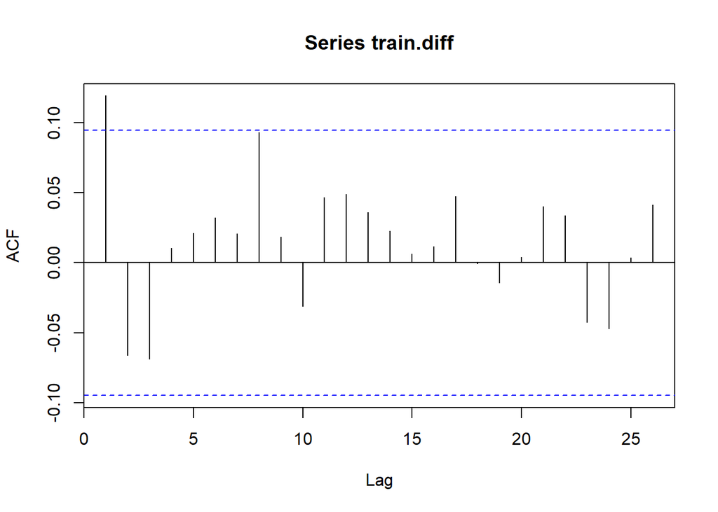

```r
acf(train.diff)
```

Berdasarkan plot tersebut, terlihat bahwa plot ACF cenderung *cuts off* pada lag ke 1, sehingga jika plot PACF dianggap *tails of*, maka model tentatifnya adalah ARIMA(0,1,1).

#### 3.4.2 Plot PACF

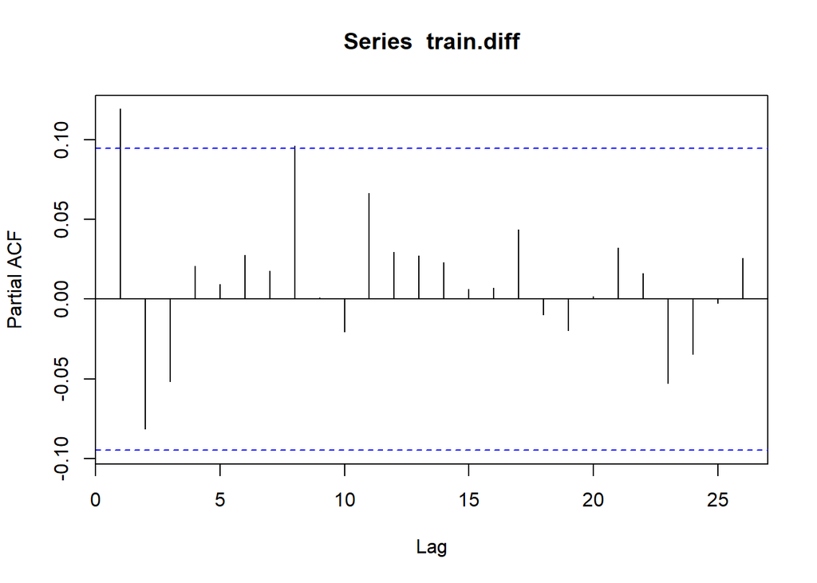

```r
pacf(train.diff)
```

Berdasarkan plot tersebut, terlihat bahwa plot PACF cenderung *cuts off* pada lag ke 1, sehingga jika plot ACF dianggap *tails of*, maka model tentatifnya adalah ARIMA(1,1,0).

Jika baik plot ACF maupun plot PACF keduanya dianggap tails of, maka model yang terbentuk adalah ARIMA(1,1,1)

#### 3.4.3 Plot EACF

```r
eacf(train.diff)
```

```
AR/MA
  0 1 2 3 4 5 6 7 8 9 10 11 12 13
0 x o o o o o o o o o o  o  o  o
1 x x o o o o o o o o o  o  o  o
2 x x o o o o o o o o o  o  o  o
3 x x o o o o o o o o o  o  o  o
4 x x x o o o o o o o o  o  o  o
5 x x o o o o o o o o o  o  o  o
6 x x o o x x o o o o o  o  o  o
7 x x o x x x x o o o o  o  o  o
```

### 3.5 Pendugaan Parameter Model Tentatif

#### 3.5.1 ARIMA(0,1,1)

```r
model1.da=Arima(train.diff, order=c(0,0,1),method="ML")
summary(model1.da) #AIC=4752.56
```

```
Series: train.diff
ARIMA(0,0,1) with non-zero mean

Coefficients:
         ma1    mean
      0.1352  7.1077
s.e.  0.0498  3.3499

sigma^2 = 3756:  log likelihood = -2373.28
AIC=4752.56   AICc=4752.62   BIC=4764.75

Training set error measures:
                       ME  RMSE      MAE  MPE MAPE      MASE         ACF1
Training set -0.005374792 61.14 43.42061 -Inf  Inf 0.7396625 -0.006155765
```

```r
lmtest::coeftest(model1.da) #seluruh parameter signifikan
```

```
z test of coefficients:

          Estimate Std. Error z value Pr(>|z|)
ma1       0.135154   0.049751  2.7166 0.006596 **
intercept 7.107718   3.349898  2.1218 0.033857 *
---
Signif. codes:  0 '***' 0.001 '**' 0.01 '*' 0.05 '.' 0.1 ' ' 1
```

#### 3.5.2 ARIMA(1,1,0)

```r
model2.da=Arima(train.diff, order=c(1,0,0),method="ML")
summary(model2.da) #AIC=4753.48
```

```
Series: train.diff
ARIMA(1,0,0) with non-zero mean

Coefficients:
         ar1    mean
      0.1189  7.1095
s.e.  0.0479  3.3529

sigma^2 = 3764:  log likelihood = -2373.74
AIC=4753.48   AICc=4753.54   BIC=4765.66

Training set error measures:
                       ME    RMSE      MAE  MPE MAPE      MASE        ACF1
Training set -0.005694796 61.2056 43.46036 -Inf  Inf 0.7403397 0.009939135
```

```r
lmtest::coeftest(model2.da) #seluruh parameter signifikan
```

```
z test of coefficients:

          Estimate Std. Error z value Pr(>|z|)
ar1       0.118948   0.047901  2.4832  0.01302 *
intercept 7.109487   3.352935  2.1204  0.03397 *
---
Signif. codes:  0 '***' 0.001 '**' 0.01 '*' 0.05 '.' 0.1 ' ' 1
```

#### 3.5.3 ARIMA(1,1,1)

```r
model3.da=Arima(train.diff, order=c(1,0,1),method="ML")
summary(model3.da) #AIC=4754.1
```

```
Series: train.diff
ARIMA(1,0,1) with non-zero mean

Coefficients:
          ar1     ma1    mean
      -0.1670  0.2978  7.1037
s.e.   0.2423  0.2322  3.2804

sigma^2 = 3760:  log likelihood = -2373.05
AIC=4754.1   AICc=4754.19   BIC=4770.34

Training set error measures:
                        ME     RMSE      MAE  MPE MAPE      MASE         ACF1
Training set -0.0004181006 61.10659 43.32274 -Inf  Inf 0.7379952 -0.003493016
```

```r
lmtest::coeftest(model3.da) #tidak ada parameter signifikan
```

```
z test of coefficients:

          Estimate Std. Error z value Pr(>|z|)
ar1       -0.16699    0.24228 -0.6893  0.49066
ma1        0.29784    0.23217  1.2828  0.19955
intercept  7.10366    3.28040  2.1655  0.03035 *
---
Signif. codes:  0 '***' 0.001 '**' 0.01 '*' 0.05 '.' 0.1 ' ' 1
```

#### 3.5.4 ARIMA(1,1,2)

```r
model5.da=Arima(train.diff, order=c(1,0,2),method="ML")
summary(model5.da) #AIC=4754.71
```

```
Series: train.diff
ARIMA(1,0,2) with non-zero mean

Coefficients:
         ar1      ma1      ma2    mean
      0.3945  -0.2726  -0.1087  7.1127
s.e.  0.3296   0.3270   0.0543  3.0108

sigma^2 = 3757:  log likelihood = -2372.35
AIC=4754.71   AICc=4754.85   BIC=4775.01

Training set error measures:
                    ME     RMSE      MAE  MPE MAPE      MASE        ACF1
Training set -0.009372 61.00723 43.17141 -Inf  Inf 0.7354175 0.003377215
```

```r
lmtest::coeftest(model5.da) #terdapat parameter tidak signifikan
```

```
z test of coefficients:

           Estimate Std. Error z value Pr(>|z|)
ar1        0.394546   0.329583  1.1971  0.23126
ma1       -0.272627   0.327014 -0.8337  0.40446
ma2       -0.108691   0.054328 -2.0006  0.04543 *
intercept  7.112667   3.010799  2.3624  0.01816 *
---
Signif. codes:  0 '***' 0.001 '**' 0.01 '*' 0.05 '.' 0.1 ' ' 1
```

#### 3.5.5 ARIMA(2,1,2)

```r
model6.da=Arima(train.diff, order=c(2,0,2),method="ML")
summary(model6.da) #AIC=4755.46
```

```
Series: train.diff
ARIMA(2,0,2) with non-zero mean

Coefficients:
```

```
         ar1      ar2      ma1     ma2    mean
      0.2406  -0.3519  -0.1124  0.2629  7.0944
s.e.     NaN      NaN      NaN     NaN  3.0450

sigma^2 = 3755:  log likelihood = -2371.73
AIC=4755.46   AICc=4755.66   BIC=4779.83

Training set error measures:
                      ME    RMSE      MAE  MPE MAPE      MASE         ACF1
Training set 0.007656631 60.9179 43.19401 -Inf  Inf 0.7358024 -0.002419307
```

```r
lmtest::coeftest(model6.da) #NaN
```

```
z test of coefficients:

          Estimate Std. Error z value Pr(>|z|)
ar1        0.24058        NaN     NaN      NaN
ar2       -0.35193        NaN     NaN      NaN
ma1       -0.11241        NaN     NaN      NaN
ma2        0.26285        NaN     NaN      NaN
intercept  7.09437    3.04502  2.3298  0.01982 *
---
Signif. codes:  0 '***' 0.001 '**' 0.01 '*' 0.05 '.' 0.1 ' ' 1
```

### 3.6 Ringkasan AIC

```r
model_tentatif <- data.frame(
  Model = c("ARIMA(0,1,1)","ARIMA(1,1,0)","ARIMA(1,1,1)", "ARIMA(1,1,2)",
            "ARIMA(2,1,2)"),
  AIC   = c(AIC(model1.da),AIC(model2.da), AIC(model3.da), AIC(model5.da), AIC(model6.da)),
  BIC   = c(BIC(model1.da),BIC(model2.da), BIC(model3.da), BIC(model5.da), BIC(model6.da))
)

model_tentatif
```

```
         Model      AIC      BIC
1 ARIMA(0,1,1) 4752.564 4764.749
2 ARIMA(1,1,0) 4753.480 4765.665
3 ARIMA(1,1,1) 4754.096 4770.342
4 ARIMA(1,1,2) 4754.706 4775.013
5 ARIMA(2,1,2) 4755.459 4779.828
```

Berdasarkan pendugaan parameter di atas, nilai AIC terkecil dimiliki oleh model ARIMA(0,1,1) dan parameter model ARIMA(0,1,1) juga seluruhnya signifikan sehingga model yang dipilih adalah model ARIMA(0,1,1).

### 3.7 Analisis Sisaan

Model terbaik hasil identifikasi kemudian dicek asumsi sisaannya. Sisaan model ARIMA harus memenuhi asumsi normalitas, kebebasan sisaan, dan kehomogenan ragam. Diagnostik model dilakukan secara eksplorasi dan uji formal.

#### 3.7.1 Eksplorasi Sisaan

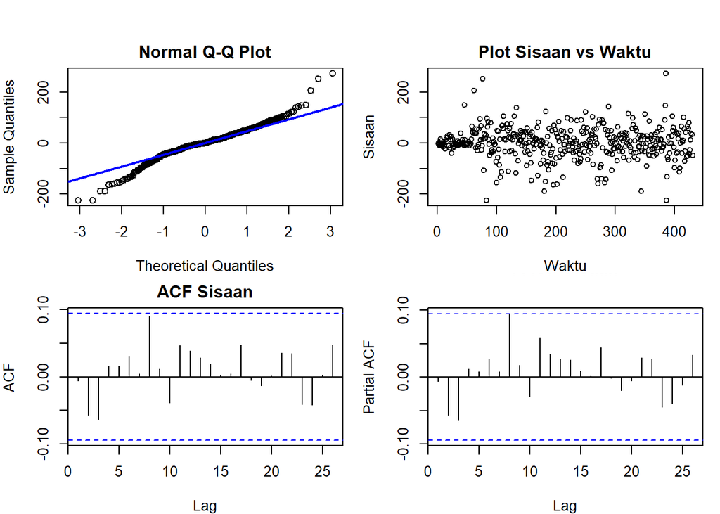

```r
sisaan.da <- model1.da$residuals

par(mfrow = c(2,2),
    mar = c(4,4,2,1),
    oma = c(0,0,2,0))

# Q-Q Plot
qqnorm(sisaan.da, main = "Normal Q-Q Plot")
qqline(sisaan.da, col = "blue", lwd = 2)

# Plot Sisaan vs Waktu
plot(sisaan.da, type = "p",
     main = "Plot Sisaan vs Waktu",
     xlab = "Waktu", ylab = "Sisaan")

# ACF
acf(sisaan.da, main = "ACF Sisaan")

# PACF
pacf(sisaan.da, main = "PACF Sisaan")
```

Berdasarkan plot kuantil-kuantil normal, secara eksploratif terlihat bahwa sisaan tidak sepenuhnya menyebar normal karena titik-titik cenderung menyimpang dari garis 45∘. Selain itu, lebar pita sebaran sisaan tampak tidak seragam, yang mengindikasikan adanya heterogenitas ragam. Sementara itu, plot ACF dan PACF sisaan dari model ARIMA(0,1,1) menunjukkan tidak adanya spike signifikan pada 20 lag pertama, sehingga secara visual sisaan dapat dianggap saling bebas. Kondisi ini akan diuji lebih lanjut dengan uji formal.